# Species metadata description

# Biodiversity mapping

The following pdf gives a description of the data used in the pipeline run that corresponds to the folder this document resides in. It should be used as a guide for anyone who wants to know more about the data used in the corresponding outputs (maps and datasets) and/or would like to replicate the data.

We begin with basic information about the pipeline run.

| Characteristic | Value |
| --- | --- |
| Date | 2024-11-04 |
| Taxa | birds |
| Region type | country |
| Region code | Norway |
| Total species | 403 |
| Total datasets used | 7 |
| DOI | 10.15468/dl.3pnbrf |

In addition to the above, data was downloaded with a maximum uncertainty regarding coordinates of 100 metres.

| taxa | species | redListedSpecies |
| --- | --- | --- |
| birds | 403 | 15 |

| dsName | dataType | observations | redListedObservations |
| --- | --- | --- | --- |
| iNaturalist Research-grade Observations | PO | 18049 | 388 |
| Norwegian Biodiversity Information Centre - Other datasets | PO | 9594 | 428 |
| Balsfjord Nature Reserves | PO | 8914 | 1139 |
| NHMO Bird collection | PO | 4202 | 4 |
| Artportalen | PO | 741 | 3 |
| ANM Zoological vertebrate collection | PO | 726 | 38 |
| Jordal | PO | 129 | 0 |

The following gives species richness for observations across the surveyed region by taxa.

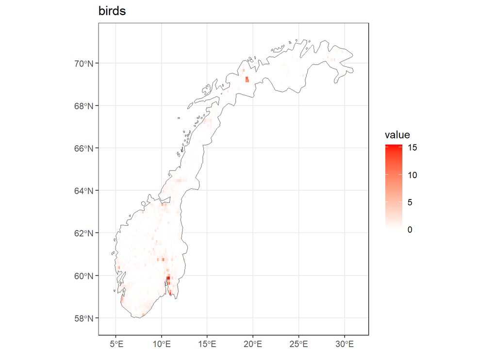

The following gives spatial density for observations across the surveyed region by taxa.

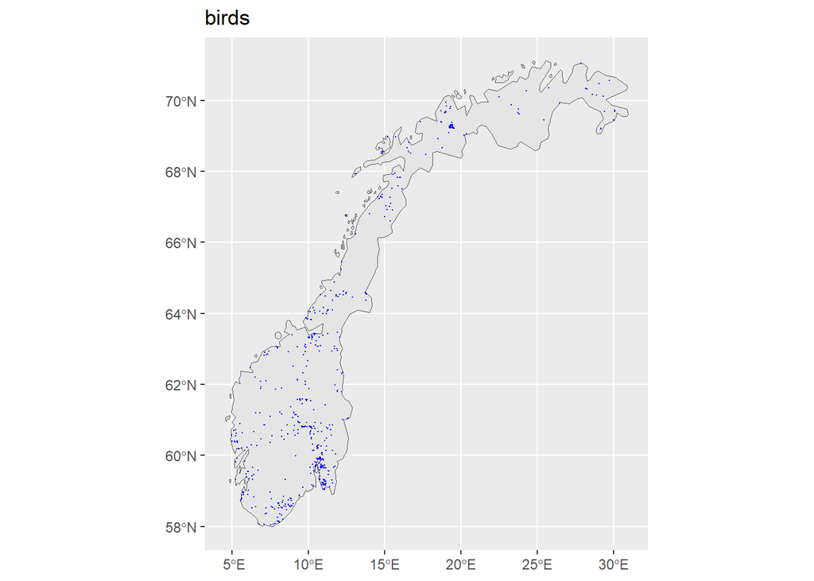

## Appendices

### Appendix 1

The tables below give further information on the observations used for our pipeline run.

Total numbers of observations used in pipeline run for each dataset by taxa.

| taxa | dsName | Observations |
| --- | --- | --- |
| birds | iNaturalist Research-grade Observations | 18049 |
| birds | Norwegian Biodiversity Information Centre - Other datasets | 9594 |
| birds | Balsfjord Nature Reserves | 8914 |
| birds | NHMO Bird collection | 4202 |
| birds | Artportalen | 741 |
| birds | ANM Zoological vertebrate collection | 726 |
| birds | Jordal | 129 |

Total numbers of observations used in pipeline run for each data type by taxa.

| taxa | dataType | Observations |
| --- | --- | --- |
| birds | PO | 42355 |